# PA!_template1

pedro pablo malagon amor

Saturday, July 19, 2014

# Reproducible Research: Peer Assessment 1

first assignment for the Reproducible Research course on Coursera. objective write a report using R markdown that can be processed by knitr package and be transformed into an HTML file.

## Loading and preprocessing the data

set the work directory `setwd()`. `raw_data` contains a data frame with the raw data used

data consists of two data sets: one for **total number of steps per day** and one for **average of steps per time interval**. Both data sets were generated using the `aggregate` function and were assigned to the objects `avg.daily_data` and `avg.interval_data`, respectively.

```r
## Set work directory
path_mydir = "C:\\Users\\pedropm\\Documents\\prog1rs\\"
setwd(path_mydir)

## Load data
raw_data = read.csv("activity.csv", header=TRUE)

## Dataset: total steps per day
avg.daily_data        = aggregate(raw_data$steps, by=list(raw_data$date), sum, na.rm=TRUE)
# Column names
names(avg.daily_data) = c("date", "total.steps")

## Dataset: average steps per interval
# Interval as factor
raw_data$interval        = as.factor(raw_data$interval)
# Dataset
avg.interval_data        = aggregate(raw_data$steps, by=list(raw_data$interval), mean, na.rm=TRUE)
# Column names
names(avg.interval_data) = c("interval","avg.steps")
```

## What is mean total number of steps taken per day?

The `avg.daily_data` data set used to answer. The mean total number of steps taken per day was assigned to the object `total.steps_mean` and the median was assigned to the `total.steps_median`.

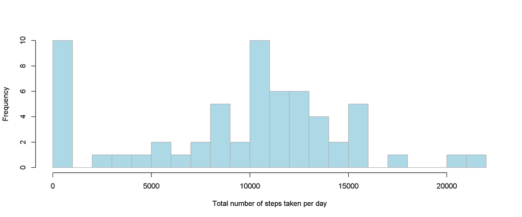

```r
## Histogram of the total number of steps taken each day
hist(avg.daily_data$total.steps, xlab="Total number of steps taken per day", breaks=20, col="lightblue", border="darkgrey", main="")
```

```r
## Mean and median of the total number of steps taken per day
total.steps_mean   = mean(avg.daily_data$total.steps)
total.steps_mean
```

```
## [1] 9354
```

```r
total.steps_median = median(avg.daily_data$total.steps)
total.steps_median
```

```
## [1] 10395
```

The mean total number of steps taken per day is equal to **9354**, whereas the median is **10395**.

## What is the average daily activity pattern?

The `avg.interval_data` data set was used to answer this question.

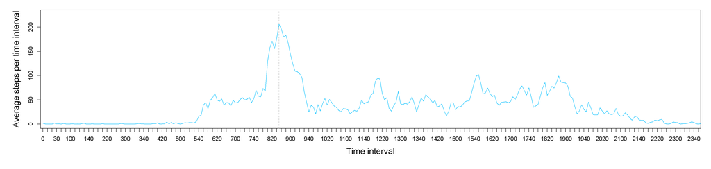

```r
## Time series plot of the 5-minute interval and the average number of steps taken
# Graph margins
par(mar=c(6,6,1.5,1.5))
plot(1:288, avg.interval_data$avg.steps, xlab="Time interval", ylab="Average steps per time interval", xlim=c(0,288), ylim=c(0,max(avg.interval_data$avg.steps)+20), xaxs="i", xaxt="n", type="l", col="deepskyblue", cex=1.5, cex.lab=1.5)
# Labels
atlabel = seq(1, 287, by=2)
clabel  = levels(avg.interval_data$interval)
clabel  = clabel[atlabel]
axis(1, at=atlabel, labels=clabel, cex.lab=0.2)
# Plot line at interval with max avg. step value
abline(v=which.max(avg.interval_data$avg.steps), col="grey", lty=2)
```

```r
## Time interval with largest average of steps
interval_max.steps = avg.interval_data[which.max(avg.interval_data$avg.steps),]
interval_max.steps
```

```
##     interval avg.steps
## 104      835     206.2
```

On average across all the days in the dataset, the 5-minute interval **835** contains the maximum number of steps.

## Imputing missing values

The missing values were totalized based on the number of rows from the `raw_data` data set which contained *NA* values in the *steps* column. The *NA* values were firstly filled using the `na.approx()` function from the `{zoo}` package. A new data set was created with *NA* filled, named `raw_data_filled`, which was used to calculate the average total steps per day that was assigned to the object `avg.daily_data_filled`.

```r
## Total number of missing values in the raw dataset
nrow(raw_data[is.na(raw_data$steps)==TRUE,])
```

```
## [1] 2304
```

```r
## Filling missing values in the raw dataset
# install.packages("zoo") # if you don't have it installed yet
library(zoo)
```

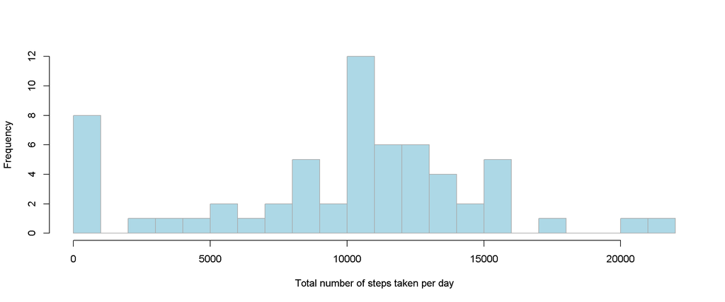

```r
raw_data_filled       = raw_data
# Fill dataset using interpolation
raw_data_filled$steps = na.approx(raw_data_filled$steps, na.rm=FALSE)
# Intervals that are still missing
still_na              = raw_data_filled[is.na(raw_data_filled$steps)==TRUE,]
still_na              = match(still_na$interval, avg.interval_data$interval)
still_na              = avg.interval_data$avg.steps[still_na]
# Fill still missing values with average of that interval
raw_data_filled$steps[is.na(raw_data_filled$steps)==TRUE] = still_na

## Dataset: total steps per day
avg.daily_data_filled = aggregate(raw_data_filled$steps, by=list(raw_data_filled$date), sum, na.rm=TRUE)
names(avg.daily_data_filled) = c("date", "total.steps")

## Histogram of the total number of steps taken each day with filled NA dataset
hist(avg.daily_data_filled$total.steps, xlab="Total number of steps taken per day", breaks=20, col="lightblue", border="darkgrey", main="")
```

```r
## Mean and median of the total number of steps taken per day with filled NA dataset
total.steps_mean_filled   = mean(avg.daily_data_filled$total.steps)
total.steps_mean_filled
```

```
## [1] 9707
```

```r
total.steps_median_filled = median(avg.daily_data_filled$total.steps)
total.steps_median_filled
```

```
## [1] 10571
```

The missing values totals **2304**. The mean total number of steps taken per day with filled gaps is equal to **9707**, whereas the median is **1.0571 × 10<sup>4</sup>**.

## Are there differences in activity patterns between weekdays and weekends?

[figure not shown]

```r
## Add Type variable to raw data filled that contains wheather date is weekday or weekend
raw_data_filled$Type = weekdays(as.Date(raw_data_filled$date))
raw_data_filled$Type = ifelse(raw_data_filled$Type == "Saturday" | raw_data_filled$Type == "Sunday", "weekend", "weekday")
raw_data_filled$Type = as.factor(raw_data_filled$Type)

## Dataset: average steps per interval with filled data
raw_data_filled$interval        = as.factor(raw_data_filled$interval)
avg.interval_data_filled        = aggregate(raw_data_filled$steps, by=list(raw_data_filled$interval, raw_data_filled$Type), mean, na.rm=TRUE)
names(avg.interval_data_filled) = c("interval", "Type", "avg.steps")

## Time series panel plot of 5-minute interval (x-axis) and the average number of steps taken give weekday type
# Labels
atlabel = seq(1, 287, by=6)
clabel  = levels(avg.interval_data$interval)
clabel  = clabel[atlabel]
# Plot
library(lattice)
xyplot(avg.steps ~ interval | Type, data=avg.interval_data_filled, layout=c(1,2), type="l", ylab="Average steps per time interval", col="deepskyblue", scales=list(x=list(at=atlabel, labels=clabel)))
```